# Risk Factor Analysis

## Outcome Variable

**Outcome Variable:** ever_swasted

## Predictor Variables

**Intervention Variable:** hhwealth_quart

**Adjustment Set:**

- arm
- sex
- W_mage
- meducyrs
- feducyrs
- W_gagebrth
- W_birthwt
- W_birthlen
- W_nchldlt5
- W_parity
- delta_W_mage
- delta_meducyrs
- delta_feducyrs
- delta_W_gagebrth
- delta_W_birthwt
- delta_W_birthlen
- delta_W_nchldlt5
- delta_W_parity

## Stratifying Variables

The analysis was stratified on these variable(s):

- agecat
- studyid
- country

## Data Summary

| agecat | studyid | country | hhwealth_quart | ever_swasted | n_cell | n |
| --- | --- | --- | --- | --- | --- | --- |
| 0-24 months | CMC-V-BCS-2002 | INDIA | Wealth Q4 | 0 | 86 | 373 |
| 0-24 months | CMC-V-BCS-2002 | INDIA | Wealth Q4 | 1 | 10 | 373 |
| 0-24 months | CMC-V-BCS-2002 | INDIA | Wealth Q1 | 0 | 66 | 373 |
| 0-24 months | CMC-V-BCS-2002 | INDIA | Wealth Q1 | 1 | 25 | 373 |
| 0-24 months | CMC-V-BCS-2002 | INDIA | Wealth Q2 | 0 | 60 | 373 |
| 0-24 months | CMC-V-BCS-2002 | INDIA | Wealth Q2 | 1 | 35 | 373 |
| 0-24 months | CMC-V-BCS-2002 | INDIA | Wealth Q3 | 0 | 69 | 373 |
| 0-24 months | CMC-V-BCS-2002 | INDIA | Wealth Q3 | 1 | 22 | 373 |
| 0-24 months | COHORTS | GUATEMALA | Wealth Q4 | 0 | 442 | 1263 |
| 0-24 months | COHORTS | GUATEMALA | Wealth Q4 | 1 | 34 | 1263 |
| 0-24 months | COHORTS | GUATEMALA | Wealth Q1 | 0 | 229 | 1263 |
| 0-24 months | COHORTS | GUATEMALA | Wealth Q1 | 1 | 15 | 1263 |
| 0-24 months | COHORTS | GUATEMALA | Wealth Q2 | 0 | 242 | 1263 |
| 0-24 months | COHORTS | GUATEMALA | Wealth Q2 | 1 | 16 | 1263 |
| 0-24 months | COHORTS | GUATEMALA | Wealth Q3 | 0 | 257 | 1263 |
| 0-24 months | COHORTS | GUATEMALA | Wealth Q3 | 1 | 28 | 1263 |
| 0-24 months | COHORTS | PHILIPPINES | Wealth Q4 | 0 | 743 | 3044 |
| 0-24 months | COHORTS | PHILIPPINES | Wealth Q4 | 1 | 97 | 3044 |
| 0-24 months | COHORTS | PHILIPPINES | Wealth Q1 | 0 | 590 | 3044 |
| 0-24 months | COHORTS | PHILIPPINES | Wealth Q1 | 1 | 91 | 3044 |
| 0-24 months | COHORTS | PHILIPPINES | Wealth Q2 | 0 | 473 | 3044 |
| 0-24 months | COHORTS | PHILIPPINES | Wealth Q2 | 1 | 67 | 3044 |
| 0-24 months | COHORTS | PHILIPPINES | Wealth Q3 | 0 | 856 | 3044 |
| 0-24 months | COHORTS | PHILIPPINES | Wealth Q3 | 1 | 127 | 3044 |
| 0-24 months | CONTENT | PERU | Wealth Q4 | 0 | 51 | 215 |
| 0-24 months | CONTENT | PERU | Wealth Q4 | 1 | 1 | 215 |
| 0-24 months | CONTENT | PERU | Wealth Q1 | 0 | 59 | 215 |
| 0-24 months | CONTENT | PERU | Wealth Q1 | 1 | 0 | 215 |
| 0-24 months | CONTENT | PERU | Wealth Q2 | 0 | 52 | 215 |
| 0-24 months | CONTENT | PERU | Wealth Q2 | 1 | 0 | 215 |

[output cut: 114 more lines]

The following strata were considered:

- agecat: 0-24 months, studyid: CMC-V-BCS-2002, country: INDIA
- agecat: 0-24 months, studyid: COHORTS, country: GUATEMALA
- agecat: 0-24 months, studyid: COHORTS, country: PHILIPPINES
- agecat: 0-24 months, studyid: CONTENT, country: PERU
- agecat: 0-24 months, studyid: GMS-Nepal, country: NEPAL
- agecat: 0-24 months, studyid: IRC, country: INDIA
- agecat: 0-24 months, studyid: JiVitA-3, country: BANGLADESH
- agecat: 0-24 months, studyid: JiVitA-4, country: BANGLADESH
- agecat: 0-24 months, studyid: LCNI-5, country: MALAWI
- agecat: 0-24 months, studyid: MAL-ED, country: BANGLADESH
- agecat: 0-24 months, studyid: MAL-ED, country: BRAZIL
- agecat: 0-24 months, studyid: MAL-ED, country: INDIA
- agecat: 0-24 months, studyid: MAL-ED, country: NEPAL
- agecat: 0-24 months, studyid: MAL-ED, country: PERU
- agecat: 0-24 months, studyid: MAL-ED, country: SOUTH AFRICA
- agecat: 0-24 months, studyid: MAL-ED, country: TANZANIA, UNITED REPUBLIC OF
- agecat: 0-24 months, studyid: PROVIDE, country: BANGLADESH
- agecat: 0-24 months, studyid: TanzaniaChild2, country: TANZANIA, UNITED REPUBLIC OF

### Dropped Strata

Some strata were dropped due to rare outcomes:

- agecat: 0-24 months, studyid: CONTENT, country: PERU
- agecat: 0-24 months, studyid: LCNI-5, country: MALAWI
- agecat: 0-24 months, studyid: MAL-ED, country: BANGLADESH
- agecat: 0-24 months, studyid: MAL-ED, country: BRAZIL
- agecat: 0-24 months, studyid: MAL-ED, country: INDIA
- agecat: 0-24 months, studyid: MAL-ED, country: NEPAL
- agecat: 0-24 months, studyid: MAL-ED, country: PERU
- agecat: 0-24 months, studyid: MAL-ED, country: SOUTH AFRICA
- agecat: 0-24 months, studyid: MAL-ED, country: TANZANIA, UNITED REPUBLIC OF

## Methods Detail

We're interested in the causal parameters $E[Y_a]$ for all values of $a \in \mathcal{A}$. These parameters represent the mean outcome if, possibly contrary to fact, we intervened to set all units to have $A=a$. Under the randomization and positivity assumptions, these are identified by the statistical parameters $\psi_a=E_W[E_{Y|A,W}(Y|A=a,W)]$. In addition, we're interested in the mean of $Y$, $E[Y]$ under no intervention (the observed mean). We will estimate these parameters by using SuperLearner to fit the relevant likelihood factors -- $E_{Y|A,W}(Y|A=a,W)$ and $p(A=a|W)$, and then updating our likelihood fit using a joint TMLE.

For unadjusted analyses ($W=\{\}$), initial likelihoods were estimated using Lrnr_glm to estimate the simple $E(Y|A)$ and Lrnr_mean to estimate $p(A)$. For adjusted analyses, a small library containing Lrnr_glmnet, Lrnr_xgboost, and Lrnr_mean was used.

Having estimated these parameters, we will then use the delta method to estimate relative risks and attributable risks relative to a prespecified baseline level of $A$.

# Results Detail

## Results Plots

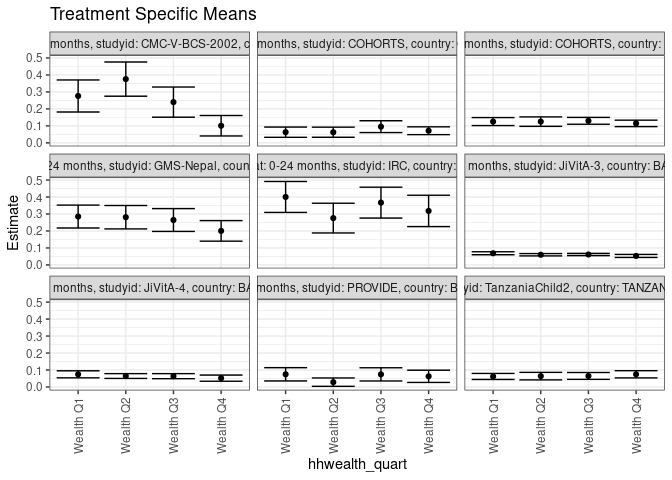

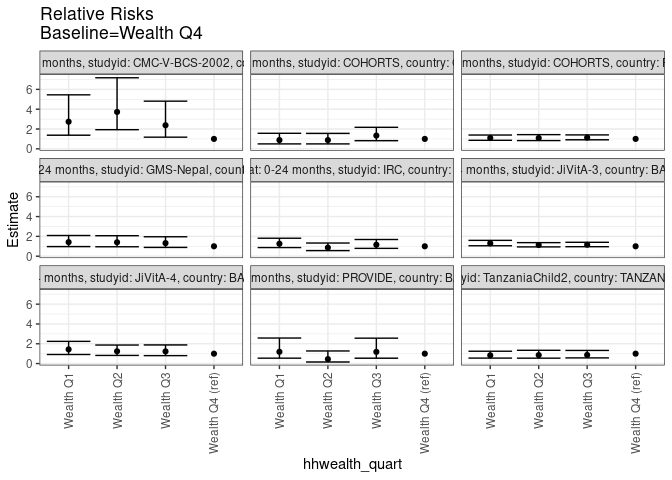

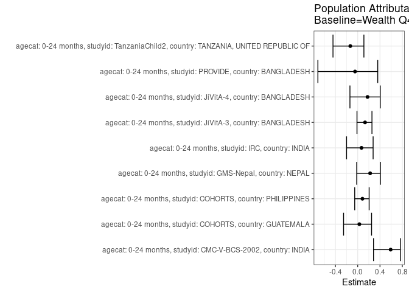

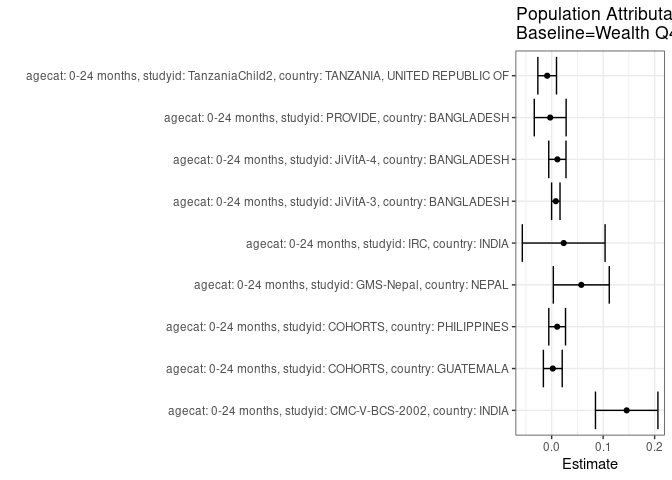

## Results Table

### Parameter: TSM

| agecat | studyid | country | intervention_level | baseline_level | estimate | ci_lower | ci_upper |
| --- | --- | --- | --- | --- | --- | --- | --- |
| 0-24 months | CMC-V-BCS-2002 | INDIA | Wealth Q4 | NA | 0.1009022 | 0.0405648 | 0.1612395 |
| 0-24 months | CMC-V-BCS-2002 | INDIA | Wealth Q1 | NA | 0.2761789 | 0.1818299 | 0.3705279 |
| 0-24 months | CMC-V-BCS-2002 | INDIA | Wealth Q2 | NA | 0.3755693 | 0.2748662 | 0.4762725 |
| 0-24 months | CMC-V-BCS-2002 | INDIA | Wealth Q3 | NA | 0.2400720 | 0.1511719 | 0.3289720 |
| 0-24 months | COHORTS | GUATEMALA | Wealth Q4 | NA | 0.0714422 | 0.0484795 | 0.0944049 |
| 0-24 months | COHORTS | GUATEMALA | Wealth Q1 | NA | 0.0629550 | 0.0328167 | 0.0930933 |
| 0-24 months | COHORTS | GUATEMALA | Wealth Q2 | NA | 0.0627677 | 0.0330680 | 0.0924675 |
| 0-24 months | COHORTS | GUATEMALA | Wealth Q3 | NA | 0.0954607 | 0.0605785 | 0.1303429 |
| 0-24 months | COHORTS | PHILIPPINES | Wealth Q4 | NA | 0.1148217 | 0.0957865 | 0.1338569 |
| 0-24 months | COHORTS | PHILIPPINES | Wealth Q1 | NA | 0.1254003 | 0.1018272 | 0.1489734 |
| 0-24 months | COHORTS | PHILIPPINES | Wealth Q2 | NA | 0.1252677 | 0.0974638 | 0.1530717 |
| 0-24 months | COHORTS | PHILIPPINES | Wealth Q3 | NA | 0.1299263 | 0.1098298 | 0.1500228 |
| 0-24 months | GMS-Nepal | NEPAL | Wealth Q4 | NA | 0.2004498 | 0.1398103 | 0.2610892 |
| 0-24 months | GMS-Nepal | NEPAL | Wealth Q1 | NA | 0.2849642 | 0.2174819 | 0.3524465 |
| 0-24 months | GMS-Nepal | NEPAL | Wealth Q2 | NA | 0.2811655 | 0.2122992 | 0.3500317 |
| 0-24 months | GMS-Nepal | NEPAL | Wealth Q3 | NA | 0.2645271 | 0.1972659 | 0.3317883 |
| 0-24 months | IRC | INDIA | Wealth Q4 | NA | 0.3180884 | 0.2256876 | 0.4104892 |
| 0-24 months | IRC | INDIA | Wealth Q1 | NA | 0.4002613 | 0.3091453 | 0.4913773 |
| 0-24 months | IRC | INDIA | Wealth Q2 | NA | 0.2757663 | 0.1882880 | 0.3632446 |
| 0-24 months | IRC | INDIA | Wealth Q3 | NA | 0.3669706 | 0.2760150 | 0.4579263 |
| 0-24 months | JiVitA-3 | BANGLADESH | Wealth Q4 | NA | 0.0529938 | 0.0442102 | 0.0617773 |
| 0-24 months | JiVitA-3 | BANGLADESH | Wealth Q1 | NA | 0.0687485 | 0.0600384 | 0.0774585 |
| 0-24 months | JiVitA-3 | BANGLADESH | Wealth Q2 | NA | 0.0600497 | 0.0530693 | 0.0670300 |
| 0-24 months | JiVitA-3 | BANGLADESH | Wealth Q3 | NA | 0.0614344 | 0.0549169 | 0.0679519 |
| 0-24 months | JiVitA-4 | BANGLADESH | Wealth Q4 | NA | 0.0519254 | 0.0337117 | 0.0701392 |
| 0-24 months | JiVitA-4 | BANGLADESH | Wealth Q1 | NA | 0.0745552 | 0.0538584 | 0.0952521 |
| 0-24 months | JiVitA-4 | BANGLADESH | Wealth Q2 | NA | 0.0644276 | 0.0503575 | 0.0784978 |
| 0-24 months | JiVitA-4 | BANGLADESH | Wealth Q3 | NA | 0.0637624 | 0.0488925 | 0.0786324 |
| 0-24 months | PROVIDE | BANGLADESH | Wealth Q4 | NA | 0.0628571 | 0.0268723 | 0.0988420 |
| 0-24 months | PROVIDE | BANGLADESH | Wealth Q1 | NA | 0.0747126 | 0.0356178 | 0.1138075 |
| 0-24 months | PROVIDE | BANGLADESH | Wealth Q2 | NA | 0.0284091 | 0.0038466 | 0.0529716 |
| 0-24 months | PROVIDE | BANGLADESH | Wealth Q3 | NA | 0.0742857 | 0.0354053 | 0.1131661 |
| 0-24 months | TanzaniaChild2 | TANZANIA, UNITED REPUBLIC OF | Wealth Q4 | NA | 0.0745784 | 0.0533626 | 0.0957941 |
| 0-24 months | TanzaniaChild2 | TANZANIA, UNITED REPUBLIC OF | Wealth Q1 | NA | 0.0619830 | 0.0442164 | 0.0797496 |
| 0-24 months | TanzaniaChild2 | TANZANIA, UNITED REPUBLIC OF | Wealth Q2 | NA | 0.0638859 | 0.0418185 | 0.0859534 |
| 0-24 months | TanzaniaChild2 | TANZANIA, UNITED REPUBLIC OF | Wealth Q3 | NA | 0.0649765 | 0.0447336 | 0.0852193 |

### Parameter: E(Y)

| agecat | studyid | country | intervention_level | baseline_level | estimate | ci_lower | ci_upper |
| --- | --- | --- | --- | --- | --- | --- | --- |
| 0-24 months | CMC-V-BCS-2002 | INDIA | NA | NA | 0.2466488 | 0.2028447 | 0.2904529 |
| 0-24 months | COHORTS | GUATEMALA | NA | NA | 0.0736342 | 0.0592247 | 0.0880437 |
| 0-24 months | COHORTS | PHILIPPINES | NA | NA | 0.1254928 | 0.1137225 | 0.1372631 |
| 0-24 months | GMS-Nepal | NEPAL | NA | NA | 0.2580175 | 0.2252514 | 0.2907836 |
| 0-24 months | IRC | INDIA | NA | NA | 0.3414634 | 0.2955068 | 0.3874201 |
| 0-24 months | JiVitA-3 | BANGLADESH | NA | NA | 0.0610426 | 0.0575617 | 0.0645236 |
| 0-24 months | JiVitA-4 | BANGLADESH | NA | NA | 0.0630182 | 0.0560941 | 0.0699424 |
| 0-24 months | PROVIDE | BANGLADESH | NA | NA | 0.0600000 | 0.0423945 | 0.0776055 |
| 0-24 months | TanzaniaChild2 | TANZANIA, UNITED REPUBLIC OF | NA | NA | 0.0658557 | 0.0558973 | 0.0758141 |

### Parameter: RR

| agecat | studyid | country | intervention_level | baseline_level | estimate | ci_lower | ci_upper |
| --- | --- | --- | --- | --- | --- | --- | --- |
| 0-24 months | CMC-V-BCS-2002 | INDIA | Wealth Q4 | Wealth Q4 | 1.0000000 | 1.0000000 | 1.000000 |
| 0-24 months | CMC-V-BCS-2002 | INDIA | Wealth Q1 | Wealth Q4 | 2.7370961 | 1.3744311 | 5.450760 |
| 0-24 months | CMC-V-BCS-2002 | INDIA | Wealth Q2 | Wealth Q4 | 3.7221141 | 1.9318091 | 7.171585 |
| 0-24 months | CMC-V-BCS-2002 | INDIA | Wealth Q3 | Wealth Q4 | 2.3792550 | 1.1767810 | 4.810457 |
| 0-24 months | COHORTS | GUATEMALA | Wealth Q4 | Wealth Q4 | 1.0000000 | 1.0000000 | 1.000000 |
| 0-24 months | COHORTS | GUATEMALA | Wealth Q1 | Wealth Q4 | 0.8812014 | 0.4959729 | 1.565642 |
| 0-24 months | COHORTS | GUATEMALA | Wealth Q2 | Wealth Q4 | 0.8785803 | 0.4962840 | 1.555366 |
| 0-24 months | COHORTS | GUATEMALA | Wealth Q3 | Wealth Q4 | 1.3361949 | 0.8221764 | 2.171574 |
| 0-24 months | COHORTS | PHILIPPINES | Wealth Q4 | Wealth Q4 | 1.0000000 | 1.0000000 | 1.000000 |
| 0-24 months | COHORTS | PHILIPPINES | Wealth Q1 | Wealth Q4 | 1.0921308 | 0.8573317 | 1.391235 |
| 0-24 months | COHORTS | PHILIPPINES | Wealth Q2 | Wealth Q4 | 1.0909763 | 0.8312013 | 1.431939 |
| 0-24 months | COHORTS | PHILIPPINES | Wealth Q3 | Wealth Q4 | 1.1315486 | 0.9100315 | 1.406987 |
| 0-24 months | GMS-Nepal | NEPAL | Wealth Q4 | Wealth Q4 | 1.0000000 | 1.0000000 | 1.000000 |
| 0-24 months | GMS-Nepal | NEPAL | Wealth Q1 | Wealth Q4 | 1.4216242 | 0.9680328 | 2.087755 |
| 0-24 months | GMS-Nepal | NEPAL | Wealth Q2 | Wealth Q4 | 1.4026730 | 0.9502928 | 2.070406 |
| 0-24 months | GMS-Nepal | NEPAL | Wealth Q3 | Wealth Q4 | 1.3196678 | 0.8885957 | 1.959860 |
| 0-24 months | IRC | INDIA | Wealth Q4 | Wealth Q4 | 1.0000000 | 1.0000000 | 1.000000 |
| 0-24 months | IRC | INDIA | Wealth Q1 | Wealth Q4 | 1.2583336 | 0.8725275 | 1.814732 |
| 0-24 months | IRC | INDIA | Wealth Q2 | Wealth Q4 | 0.8669488 | 0.5647693 | 1.330809 |
| 0-24 months | IRC | INDIA | Wealth Q3 | Wealth Q4 | 1.1536751 | 0.7903991 | 1.683917 |
| 0-24 months | JiVitA-3 | BANGLADESH | Wealth Q4 | Wealth Q4 | 1.0000000 | 1.0000000 | 1.000000 |
| 0-24 months | JiVitA-3 | BANGLADESH | Wealth Q1 | Wealth Q4 | 1.2972932 | 1.0525460 | 1.598951 |
| 0-24 months | JiVitA-3 | BANGLADESH | Wealth Q2 | Wealth Q4 | 1.1331458 | 0.9371330 | 1.370157 |
| 0-24 months | JiVitA-3 | BANGLADESH | Wealth Q3 | Wealth Q4 | 1.1592748 | 0.9593096 | 1.400922 |
| 0-24 months | JiVitA-4 | BANGLADESH | Wealth Q4 | Wealth Q4 | 1.0000000 | 1.0000000 | 1.000000 |
| 0-24 months | JiVitA-4 | BANGLADESH | Wealth Q1 | Wealth Q4 | 1.4358133 | 0.9187090 | 2.243975 |
| 0-24 months | JiVitA-4 | BANGLADESH | Wealth Q2 | Wealth Q4 | 1.2407716 | 0.8219924 | 1.872906 |
| 0-24 months | JiVitA-4 | BANGLADESH | Wealth Q3 | Wealth Q4 | 1.2279614 | 0.8013180 | 1.881761 |
| 0-24 months | PROVIDE | BANGLADESH | Wealth Q4 | Wealth Q4 | 1.0000000 | 1.0000000 | 1.000000 |
| 0-24 months | PROVIDE | BANGLADESH | Wealth Q1 | Wealth Q4 | 1.1886102 | 0.5472702 | 2.581529 |
| 0-24 months | PROVIDE | BANGLADESH | Wealth Q2 | Wealth Q4 | 0.4519628 | 0.1602357 | 1.274812 |
| 0-24 months | PROVIDE | BANGLADESH | Wealth Q3 | Wealth Q4 | 1.1818182 | 0.5440987 | 2.566987 |
| 0-24 months | TanzaniaChild2 | TANZANIA, UNITED REPUBLIC OF | Wealth Q4 | Wealth Q4 | 1.0000000 | 1.0000000 | 1.000000 |
| 0-24 months | TanzaniaChild2 | TANZANIA, UNITED REPUBLIC OF | Wealth Q1 | Wealth Q4 | 0.8311120 | 0.5549325 | 1.244741 |
| 0-24 months | TanzaniaChild2 | TANZANIA, UNITED REPUBLIC OF | Wealth Q2 | Wealth Q4 | 0.8566283 | 0.5475140 | 1.340262 |
| 0-24 months | TanzaniaChild2 | TANZANIA, UNITED REPUBLIC OF | Wealth Q3 | Wealth Q4 | 0.8712506 | 0.5714734 | 1.328282 |

### Parameter: PAR

| agecat | studyid | country | intervention_level | baseline_level | estimate | ci_lower | ci_upper |
| --- | --- | --- | --- | --- | --- | --- | --- |
| 0-24 months | CMC-V-BCS-2002 | INDIA | Wealth Q4 | NA | 0.1457466 | 0.0850846 | 0.2064087 |
| 0-24 months | COHORTS | GUATEMALA | Wealth Q4 | NA | 0.0021920 | -0.0160968 | 0.0204808 |
| 0-24 months | COHORTS | PHILIPPINES | Wealth Q4 | NA | 0.0106711 | -0.0055835 | 0.0269256 |
| 0-24 months | GMS-Nepal | NEPAL | Wealth Q4 | NA | 0.0575677 | 0.0032327 | 0.1119028 |
| 0-24 months | IRC | INDIA | Wealth Q4 | NA | 0.0233750 | -0.0570257 | 0.1037758 |
| 0-24 months | JiVitA-3 | BANGLADESH | Wealth Q4 | NA | 0.0080488 | -0.0001207 | 0.0162184 |
| 0-24 months | JiVitA-4 | BANGLADESH | Wealth Q4 | NA | 0.0110928 | -0.0056562 | 0.0278418 |
| 0-24 months | PROVIDE | BANGLADESH | Wealth Q4 | NA | -0.0028571 | -0.0337992 | 0.0280849 |
| 0-24 months | TanzaniaChild2 | TANZANIA, UNITED REPUBLIC OF | Wealth Q4 | NA | -0.0087227 | -0.0268306 | 0.0093852 |

### Parameter: PAF

| agecat | studyid | country | intervention_level | baseline_level | estimate | ci_lower | ci_upper |
| --- | --- | --- | --- | --- | --- | --- | --- |
| 0-24 months | CMC-V-BCS-2002 | INDIA | Wealth Q4 | NA | 0.5909076 | 0.2838139 | 0.7663225 |
| 0-24 months | COHORTS | GUATEMALA | Wealth Q4 | NA | 0.0297685 | -0.2531687 | 0.2488249 |
| 0-24 months | COHORTS | PHILIPPINES | Wealth Q4 | NA | 0.0850335 | -0.0534200 | 0.2052896 |
| 0-24 months | GMS-Nepal | NEPAL | Wealth Q4 | NA | 0.2231156 | -0.0176345 | 0.4069096 |
| 0-24 months | IRC | INDIA | Wealth Q4 | NA | 0.0684555 | -0.1996060 | 0.2766165 |
| 0-24 months | JiVitA-3 | BANGLADESH | Wealth Q4 | NA | 0.1318561 | -0.0128280 | 0.2558718 |
| 0-24 months | JiVitA-4 | BANGLADESH | Wealth Q4 | NA | 0.1760251 | -0.1389722 | 0.4039059 |
| 0-24 months | PROVIDE | BANGLADESH | Wealth Q4 | NA | -0.0476190 | -0.7136457 | 0.3595492 |
| 0-24 months | TanzaniaChild2 | TANZANIA, UNITED REPUBLIC OF | Wealth Q4 | NA | -0.1324512 | -0.4429676 | 0.1112442 |